# Evidence 1

José Gabriel Usiña Mogro

2022-08-26

# Introduction

Linear regression is one of the simlpest ways of prediction in machine learning. It is important because it let is know how a indepedent variable explain a depedent variable so then we can predict this variable in more accurate way for the future with the the samllet error as possible.

# Background

- **Economic Growing**

People is recovering their economic since COVID-19 so this means that the economic environment is supporting the growth of the credit cards. Also this is impacted by the increase on the minimum wage of USCMA

- **Unbanked population diminshing**

With more technology in the market, the financial companies are getting into the lives of the population making them get into banking life. This helps because this bank users are potential users of a credit card so this means more clients in the market.

# Description of the Problem Situation

The Problem Situation tell us about Financiera Ma, a financial company that provides services of credit card in Mexico. The problem is that the use of credit card is not going so good as they expected at the beginning of the year. In this case they compare the use of credit card with countries like Argentina or Brazil, and we can see that there is a big difference between them.

The solution is that we could build models that help to see what factors motivate to use credit card in Mexico and know the rates of population using the credit card, so in Financiera Ma can make better calls in order to improve their income

# Data ande Methodology

## Importing data

```r
data_ps<-read.csv("ev1_data.csv")
```

## Describing dataset

```r
str(data_ps)
```

```
## 'data.frame':    3415 obs. of  8 variables:
##  $ region   : int  3 3 3 3 3 3 3 3 3 3 ...
##  $ useCard  : int  15 4 0 0 0 1 4 1 10 0 ...
##  $ dCard    : int  1 1 0 0 0 1 1 1 1 0 ...
##  $ income   : num  17 15 0 0 0 ...
##  $ education: int  1 1 0 0 0 0 1 1 1 1 ...
##  $ age      : int  45 29 56 68 72 67 57 63 50 35 ...
##  $ age2     : int  2025 841 3136 4624 5184 4489 3249 3969 2500 1225 ...
##  $ dPhone   : int  1 1 1 0 0 1 1 1 1 1 ...
```

```r
colSums(is.na(data_ps))
```

```
##    region   useCard     dCard    income education       age      age2    dPhone
##         0         0         0       238         0         0         0         0
```

We have 238 NA´s in the monthly income

## Transforming Data

For this case we are going to change some variables as factor in order to have a better understanding of our variables

```r
data_ps$region<-as.factor(data_ps$region)
data_ps$dCard<-as.factor(data_ps$dCard)
data_ps$education<-as.factor(data_ps$education)
data_ps$dPhone<-as.factor(data_ps$dPhone)
```

We have to assume that the monthly income is in thousands Also we have to consider that we have a variable called Age2, this variable contains the age squared that we can use in one of the models that we are going to do

We are going to replace the Na’s with the median

```r
data_ps$income[is.na(data_ps$income)]<-median(data_ps$income,na.rm=TRUE)
```

## Descriptive Statistics

```r
summary(data_ps)
```

```
##  region     useCard       dCard        income      education      age
##  1:777   Min.   : 0.000   0:1791   Min.   : 0.00   0:2051    Min.   :18.00
##  2:612   1st Qu.: 0.000   1:1624   1st Qu.: 0.00   1:1364    1st Qu.:29.50
##  3:710   Median : 0.000            Median : 6.00             Median :39.00
##  4:224   Mean   : 1.772            Mean   : 7.56             Mean   :41.56
##  5:566   3rd Qu.: 2.000            3rd Qu.:10.00             3rd Qu.:52.00
##  6:526   Max.   :60.000            Max.   :98.00             Max.   :98.00
##       age2        dPhone
##  Min.   : 324.0   0: 389
##  1st Qu.: 870.5   1:3026
##  Median :1521.0
##  Mean   :1951.7
##  3rd Qu.:2704.0
##  Max.   :9604.0
```

We can see some outliers at age, for example we have a Maximum age of 98, something unusual considering our entire dataset. It could be a mistake, or an actually rare observation

Also we can see that we have observations with 0 on the monthly income. It is not so rare because it could be a credit card owned by a 18-year-old who is a student.

An interesting outlier that we can see is that the maxium at useCard is 60. This could be a mistake on typing, or maybe someone actually use his/her credit card 60 times per month

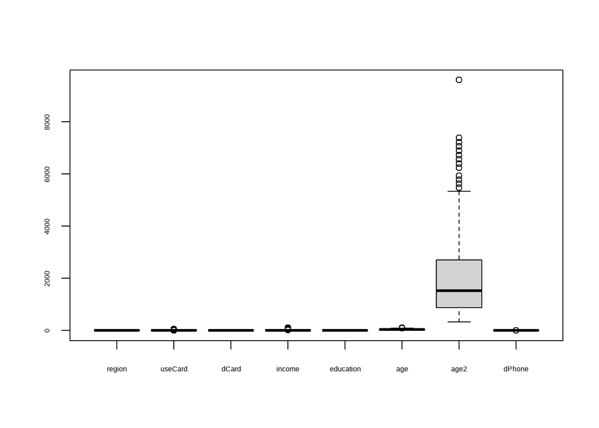

```r
boxplot(data_ps)
```

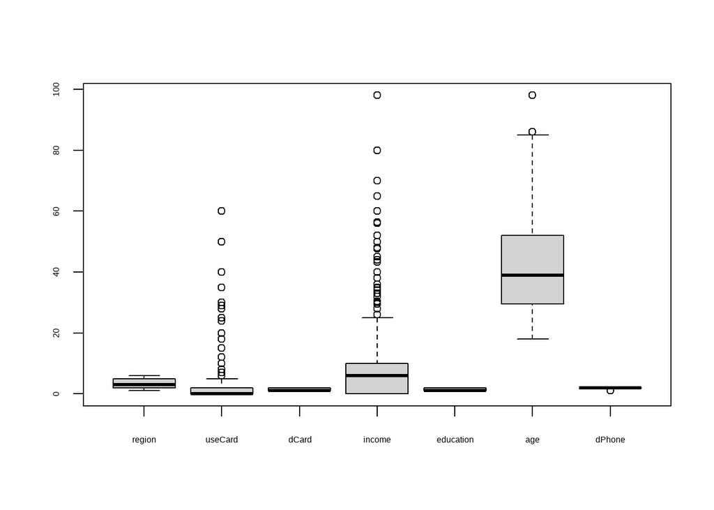

```r
boxplot(select(data_ps,-"age2")) #I dedcided to make an new boxplot without Age2 (Squared), so we could aprreciate the other boxplots better
```

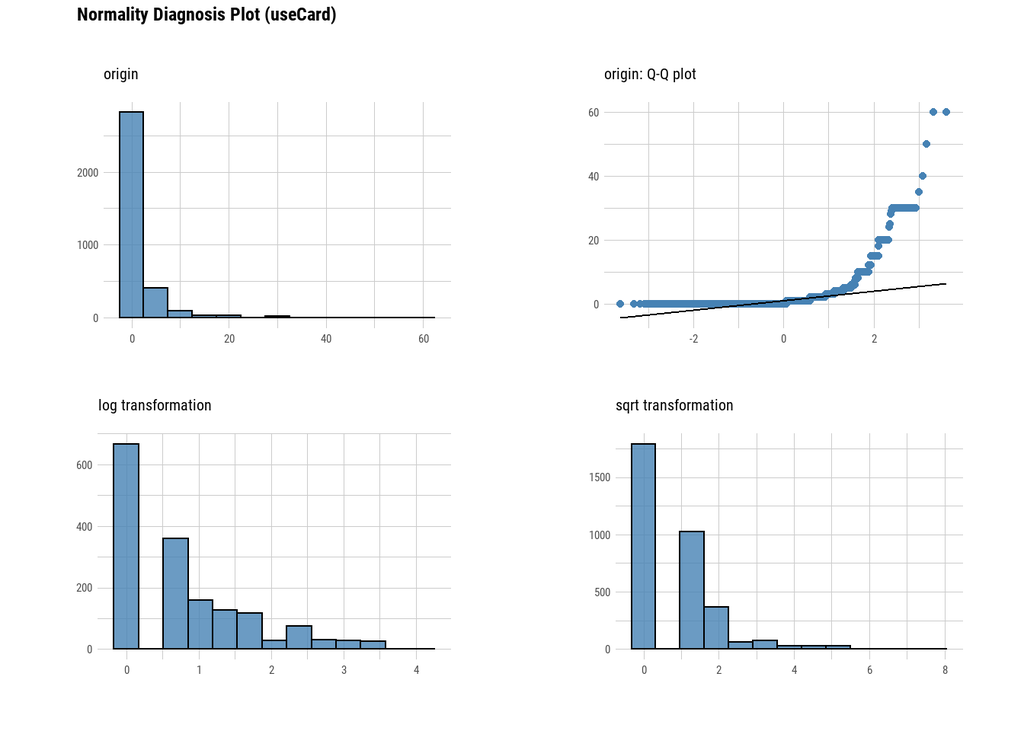

```r
plot_normality(data_ps,useCard)
```

## Data Visualization

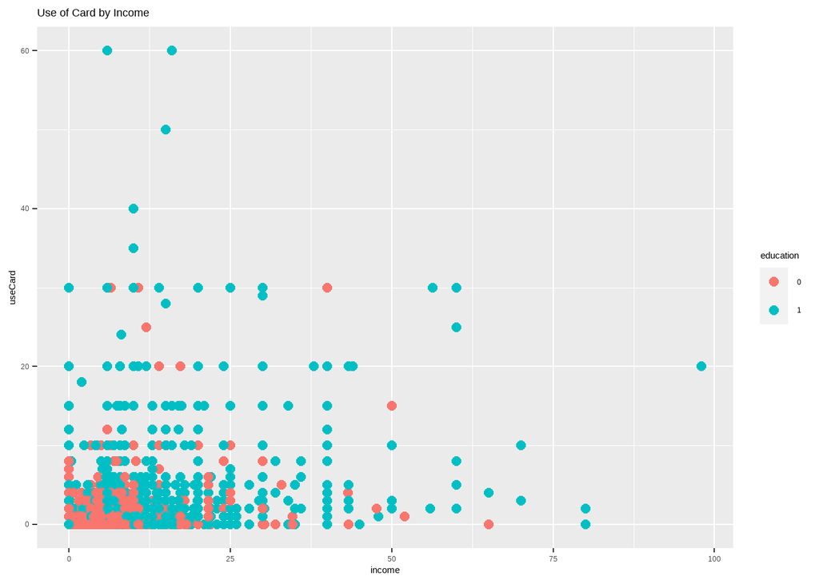

```r
ggplot(data=data_ps, mapping=aes(x=income, y=useCard, color=education)) + geom_point(size = 2.5)+labs(title="Use of Card by Income")
```

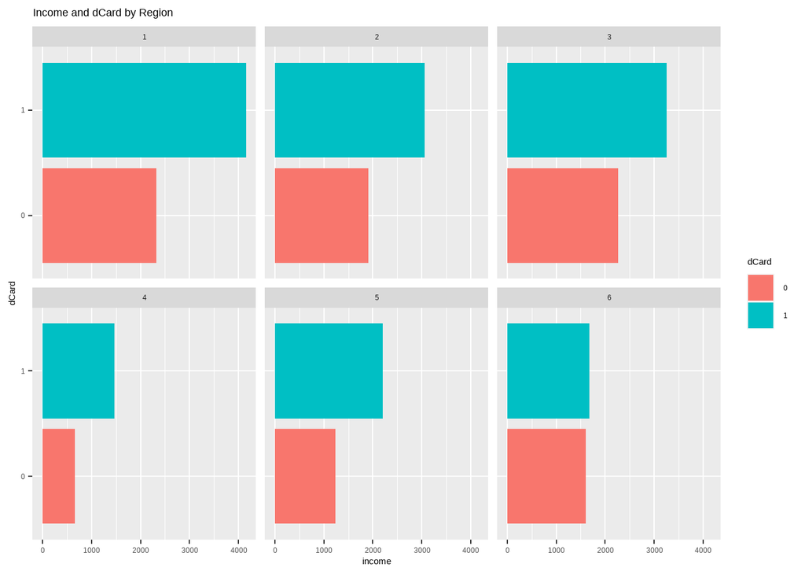

```r
ggplot(data=data_ps,aes(x=income,y=dCard,fill=dCard))+geom_bar(stat = "identity")+facet_wrap("region")+labs(title="Income and dCard by Region")
```

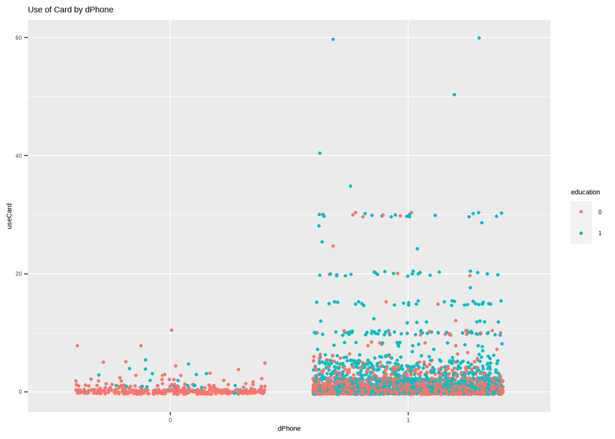

```r
ggplot(data=data_ps, mapping = aes(x=dPhone, y=useCard, color=education)) + geom_point(size=1, position='jitter')+labs(title="Use of Card by dPhone")
```

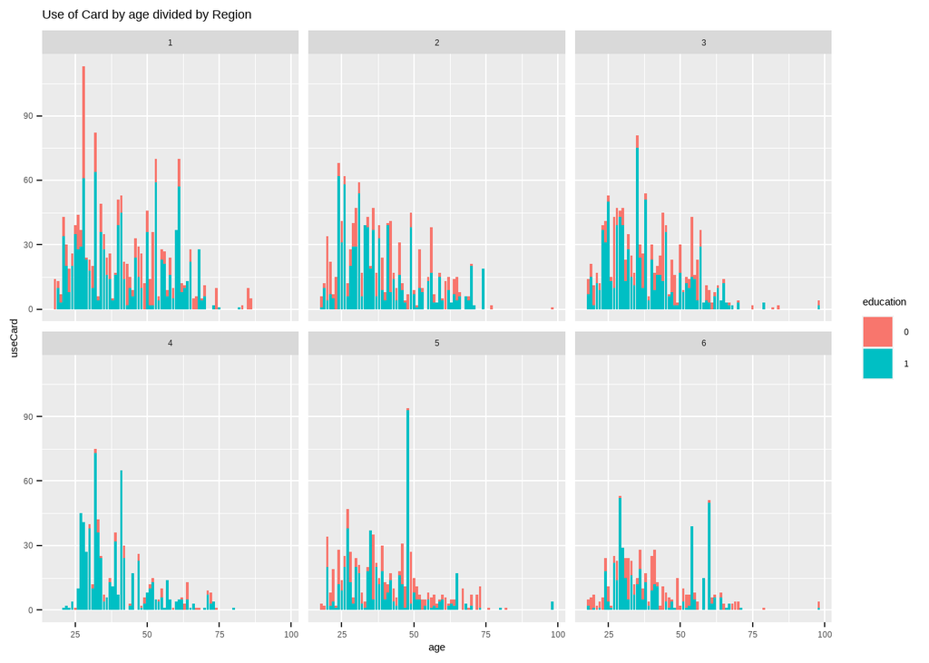

```r
ggplot(data=data_ps,mapping= aes(x=age,y=useCard,fill=education))+
  geom_bar(stat = "identity")+ facet_wrap("region")+labs(title="Use of Card by age divided by Region")
```

# Linear Regression Analysis

## Model 1

```r
model1<-lm(useCard~age+region+income+education+dPhone,data=data_ps)
summary(model1)
```

```
##
## Call:
## lm(formula = useCard ~ age + region + income + education + dPhone,
##     data = data_ps)
##
## Residuals:
##     Min      1Q  Median      3Q     Max
## -10.347  -1.513  -0.610   0.273  56.705
##
## Coefficients:
##               Estimate Std. Error t value Pr(>|t|)
## (Intercept)  0.1911525  0.3529854   0.542   0.5882
## age         -0.0009461  0.0047917  -0.197   0.8435
## region2     -0.0332122  0.2185608  -0.152   0.8792
## region3     -0.1706789  0.2103219  -0.812   0.4171
## region4      0.6488862  0.3094107   2.097   0.0361 *
## region5     -0.1338286  0.2245893  -0.596   0.5513
## region6     -0.4422293  0.2291703  -1.930   0.0537 .
## income       0.0952485  0.0082959  11.481   <2e-16 ***
## education1   1.4679255  0.1533882   9.570   <2e-16 ***
## dPhone1      0.4542988  0.2306536   1.970   0.0490 *
## ---
## Signif. codes:  0 '***' 0.001 '**' 0.01 '*' 0.05 '.' 0.1 ' ' 1
##
## Residual standard error: 4.043 on 3405 degrees of freedom
## Multiple R-squared:  0.104,  Adjusted R-squared:  0.1017
## F-statistic: 43.93 on 9 and 3405 DF,  p-value: < 2.2e-16
```

### Level of Accuracy

```r
AIC(model1)
```

```
## [1] 19244.05
```

```r
RMSE(model1$fitted.values,data_ps$useCard)
```

```
## [1] 4.036661
```

### Diagnostic Test

```r
vif(model1) #Multicollinearity Test
```

```
##               GVIF Df GVIF^(1/(2*Df))
## age       1.077415  1        1.037986
## region    1.048837  5        1.004780
## income    1.142606  1        1.068928
## education 1.179384  1        1.085994
## dPhone    1.122097  1        1.059291
```

```r
bptest(model1) #Hetereoscedasticity
```

```
##
##  studentized Breusch-Pagan test
##
## data:  model1
## BP = 79.534, df = 9, p-value = 2e-13
```

## Model 2

```r
model2<-lm(useCard~age+age2+region+income+education+dPhone,data=data_ps)
summary(model2)
```

```
##
## Call:
## lm(formula = useCard ~ age + age2 + region + income + education +
##     dPhone, data = data_ps)
##
## Residuals:
##     Min      1Q  Median      3Q     Max
## -10.417  -1.511  -0.624   0.246  56.761
##
## Coefficients:
##               Estimate Std. Error t value Pr(>|t|)
## (Intercept)  0.6754238  0.5833652   1.158   0.2470
## age         -0.0256122  0.0241372  -1.061   0.2887
## age2         0.0002679  0.0002569   1.043   0.2972
## region2     -0.0273054  0.2186314  -0.125   0.9006
## region3     -0.1643365  0.2104072  -0.781   0.4348
## region4      0.6620444  0.3096640   2.138   0.0326 *
## region5     -0.1256715  0.2247227  -0.559   0.5760
## region6     -0.4356381  0.2292545  -1.900   0.0575 .
## income       0.0967460  0.0084192  11.491   <2e-16 ***
## education1   1.4629579  0.1534602   9.533   <2e-16 ***
## dPhone1      0.4577334  0.2306742   1.984   0.0473 *
## ---
## Signif. codes:  0 '***' 0.001 '**' 0.01 '*' 0.05 '.' 0.1 ' ' 1
##
## Residual standard error: 4.043 on 3404 degrees of freedom
## Multiple R-squared:  0.1043, Adjusted R-squared:  0.1017
## F-statistic: 39.65 on 10 and 3404 DF,  p-value: < 2.2e-16
```

### Level of Accuracy

```r
AIC(model2)
```

```
## [1] 19244.96
```

```r
RMSE(model2$fitted.values,data_ps$useCard)
```

```
## [1] 4.036017
```

### Diagnostic Test

```r
vif(model2) #Multicollinearity Test
```

```
##                GVIF Df GVIF^(1/(2*Df))
## age       27.338953  1        5.228666
## age2      27.478388  1        5.241983
## region     1.051292  5        1.005015
## income     1.176855  1        1.084829
## education  1.180522  1        1.086518
## dPhone     1.122325  1        1.059399
```

```r
bptest(model2) #Hetereoscedasticity
```

```
##
##  studentized Breusch-Pagan test
##
## data:  model2
## BP = 79.433, df = 10, p-value = 6.483e-13
```

## Model 3

```r
model3<-lm(useCard~age+age2+income+dCard,data=data_ps)
summary(model3)
```

```
##
## Call:
## lm(formula = useCard ~ age + age2 + income + dCard, data = data_ps)
##
## Residuals:
##    Min     1Q Median     3Q    Max
## -7.601 -1.651 -0.093  0.423 56.599
##
## Coefficients:
##               Estimate Std. Error t value Pr(>|t|)
## (Intercept) -3.943e-01  4.904e-01  -0.804    0.421
## age         -4.652e-03  2.250e-02  -0.207    0.836
## age2         6.231e-05  2.396e-04   0.260    0.795
## income       8.323e-02  7.587e-03  10.971   <2e-16 ***
## dCard1       3.382e+00  1.332e-01  25.398   <2e-16 ***
## ---
## Signif. codes:  0 '***' 0.001 '**' 0.01 '*' 0.05 '.' 0.1 ' ' 1
##
## Residual standard error: 3.772 on 3410 degrees of freedom
## Multiple R-squared:  0.2186, Adjusted R-squared:  0.2177
## F-statistic: 238.6 on 4 and 3410 DF,  p-value: < 2.2e-16
```

### Level of Accuracy

```r
AIC(model3)
```

```
## [1] 18766.66
```

```r
RMSE(model3$fitted.values,data_ps$useCard)
```

```
## [1] 3.769664
```

### Diagnostic Test

```r
vif(model3) #Multicollinearity Test
```

```
##       age      age2    income     dCard
## 27.277909 27.439452  1.097490  1.061348
```

```r
bptest(model3) #Hetereoscedasticity
```

```
##
##  studentized Breusch-Pagan test
##
## data:  model3
## BP = 84.586, df = 4, p-value < 2.2e-16
```

## Selection of the regression model

All models have Hetereoscedasticity. It might be caused by the different regions we are analizing

## Interpretation of Results

```r
selected_model<-model1
summary(selected_model)
```

```
##
## Call:
## lm(formula = useCard ~ age + region + income + education + dPhone,
##     data = data_ps)
##
## Residuals:
##     Min      1Q  Median      3Q     Max
## -10.347  -1.513  -0.610   0.273  56.705
##
## Coefficients:
##               Estimate Std. Error t value Pr(>|t|)
## (Intercept)  0.1911525  0.3529854   0.542   0.5882
## age         -0.0009461  0.0047917  -0.197   0.8435
## region2     -0.0332122  0.2185608  -0.152   0.8792
## region3     -0.1706789  0.2103219  -0.812   0.4171
## region4      0.6488862  0.3094107   2.097   0.0361 *
## region5     -0.1338286  0.2245893  -0.596   0.5513
## region6     -0.4422293  0.2291703  -1.930   0.0537 .
## income       0.0952485  0.0082959  11.481   <2e-16 ***
## education1   1.4679255  0.1533882   9.570   <2e-16 ***
## dPhone1      0.4542988  0.2306536   1.970   0.0490 *
## ---
## Signif. codes:  0 '***' 0.001 '**' 0.01 '*' 0.05 '.' 0.1 ' ' 1
##
## Residual standard error: 4.043 on 3405 degrees of freedom
## Multiple R-squared:  0.104,  Adjusted R-squared:  0.1017
## F-statistic: 43.93 on 9 and 3405 DF,  p-value: < 2.2e-16
```

In this case we can see that the variables that better explain the useCard (*dependent variable*) are income and education one (undergraduate level or higher).

With a confidence level of 95%, another important variable is region 4, where people who lives there, increase their use of Card on 0.64

## Predicted Values

### Plot

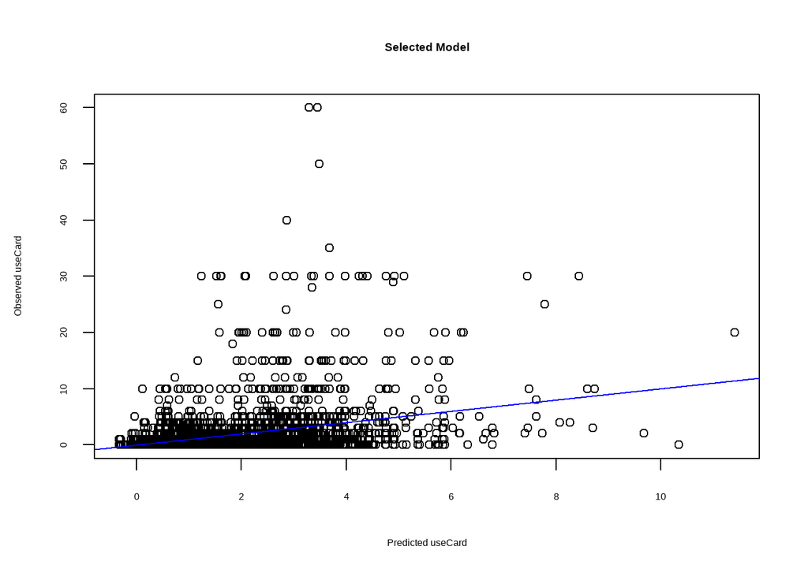

```r
plot(x=predict(selected_model),y=data_ps$useCard,
     xlab='Predicted useCard',ylab='Observed useCard',
     main='Selected Model')
abline(a=0,b=1,col="blue")
```

### Effect Plot

I decided to use income variable because it is the most important variable that is numerical

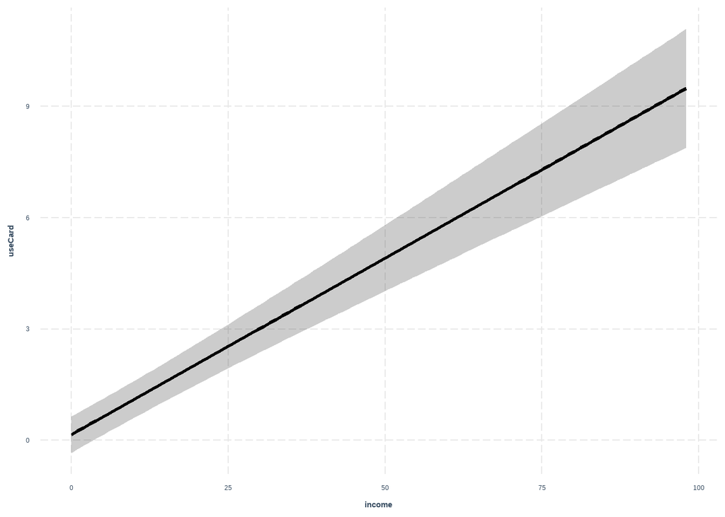

```r
effect_plot(selected_model,pred=income,interval=TRUE)
```

We can see that there is a positive relationship between income and useCard

# Conclusions and Recomendations

## Insights

Monthly income is related to have an undergraduate level or higher, and that would lead to have/use a Credit Card. This is related to the trend that was mentioned before, about the increase of the minimum wage and how this could impact in the increase of Credit Cards Market

## Strategy

It would be important to create a marketing and financial strategy to *attack* region 4 in order to get more customers for Financiera MA, in this way they are going to increase their income. The age it is not important, but monthly income is, so when they start to think about their strategy, their target should be people with a high income level.

# References

- Swaminathan, S. (2019, 18 enero). Linear Regression — Detailed View - Towards Data Science. Medium. https://towardsdatascience.com/linear-regression-detailed-view-ea73175f6e86
- Euromonitor. (s. f.). Euromonitor Login. Recuperado 25 de agosto de 2022, de https://www.portal.euromonitor.com/portal/?7axeGm%2fi3HYMzICetCZTPWrA7b3R33ioPLjyUFTSVbq%2bDH4%2f9T7Q2g%3d%3d